# **Bike Sharing Demand : Forecast use of a city bikeshare system**

- date : 2023.10.09.(월)
- author : 최호진
- project : 개인 프로젝트
- github : https://github.com/Gansaw
- tistory : https://gansaw12.tistory.com
- email : gansaw12@gmail.com

# 1. 목표

- Bike Sharing Demand 데이터를 활용하여 사용자들의 사용 패턴을 파악한다.
- 관측되는 패턴을 바탕으로 모델을 제작하여 자전거의 대여량을 예측한다.

a. 데이터 분석에 필요한 기본 library를 import한다.

```
numpy
matplotlib
pandas
seaborn
sklearn
```

```python
import numpy as np
import matplotlib.pyplot as plt
import pandas as pd
import seaborn as sns
import sklearn
```

```
train : train.csv
test : test.csv
```

```python
train = pd.read_csv("/content/train.csv")
print(train)

test = pd.read_csv("/content/test.csv")
print(test)
```

```
                  datetime  season  holiday  workingday  weather   temp  \
0      2011-01-01 00:00:00       1        0           0        1   9.84
1      2011-01-01 01:00:00       1        0           0        1   9.02
2      2011-01-01 02:00:00       1        0           0        1   9.02
3      2011-01-01 03:00:00       1        0           0        1   9.84
4      2011-01-01 04:00:00       1        0           0        1   9.84
...                    ...     ...      ...         ...      ...    ...
10881  2012-12-19 19:00:00       4        0           1        1  15.58
10882  2012-12-19 20:00:00       4        0           1        1  14.76
10883  2012-12-19 21:00:00       4        0           1        1  13.94
10884  2012-12-19 22:00:00       4        0           1        1  13.94
10885  2012-12-19 23:00:00       4        0           1        1  13.12

        atemp  humidity  windspeed  casual  registered  count
0      14.395        81     0.0000       3          13     16
```

[output cut: 39 more lines]

c. head 함수를 이용하여 데이터프레임의 상위 5개의 정보를 확인한다.

```python
train.head()
```

|  | datetime | season | holiday | workingday | weather | temp | atemp | humidity | windspeed | casual | registered | count |
| --- | --- | --- | --- | --- | --- | --- | --- | --- | --- | --- | --- | --- |
| 0 | 2011-01-01 00:00:00 | 1 | 0 | 0 | 1 | 9.84 | 14.395 | 81 | 0.0 | 3 | 13 | 16 |
| 1 | 2011-01-01 01:00:00 | 1 | 0 | 0 | 1 | 9.02 | 13.635 | 80 | 0.0 | 8 | 32 | 40 |
| 2 | 2011-01-01 02:00:00 | 1 | 0 | 0 | 1 | 9.02 | 13.635 | 80 | 0.0 | 5 | 27 | 32 |
| 3 | 2011-01-01 03:00:00 | 1 | 0 | 0 | 1 | 9.84 | 14.395 | 75 | 0.0 | 3 | 10 | 13 |
| 4 | 2011-01-01 04:00:00 | 1 | 0 | 0 | 1 | 9.84 | 14.395 | 75 | 0.0 | 0 | 1 | 1 |

```python
test.head()
```

|  | datetime | season | holiday | workingday | weather | temp | atemp | humidity | windspeed |
| --- | --- | --- | --- | --- | --- | --- | --- | --- | --- |
| 0 | 2011-01-20 00:00:00 | 1 | 0 | 1 | 1 | 10.66 | 11.365 | 56 | 26.0027 |
| 1 | 2011-01-20 01:00:00 | 1 | 0 | 1 | 1 | 10.66 | 13.635 | 56 | 0.0000 |
| 2 | 2011-01-20 02:00:00 | 1 | 0 | 1 | 1 | 10.66 | 13.635 | 56 | 0.0000 |
| 3 | 2011-01-20 03:00:00 | 1 | 0 | 1 | 1 | 10.66 | 12.880 | 56 | 11.0014 |
| 4 | 2011-01-20 04:00:00 | 1 | 0 | 1 | 1 | 10.66 | 12.880 | 56 | 11.0014 |

d. info 함수를 이용하여 기본적인 데이터 구성을 파악한다.

```python
train.info()
```

```
<class 'pandas.core.frame.DataFrame'>
RangeIndex: 10886 entries, 0 to 10885
Data columns (total 12 columns):
 #   Column      Non-Null Count  Dtype
---  ------      --------------  -----
 0   datetime    10886 non-null  object
 1   season      10886 non-null  int64
 2   holiday     10886 non-null  int64
 3   workingday  10886 non-null  int64
 4   weather     10886 non-null  int64
 5   temp        10886 non-null  float64
 6   atemp       10886 non-null  float64
 7   humidity    10886 non-null  int64
 8   windspeed   10886 non-null  float64
 9   casual      10886 non-null  int64
 10  registered  10886 non-null  int64
 11  count       10886 non-null  int64
dtypes: float64(3), int64(8), object(1)
memory usage: 1020.7+ KB
```

```python
test.info()
```

```
<class 'pandas.core.frame.DataFrame'>
RangeIndex: 6493 entries, 0 to 6492
Data columns (total 9 columns):
 #   Column      Non-Null Count  Dtype
---  ------      --------------  -----
 0   datetime    6493 non-null   object
 1   season      6493 non-null   int64
 2   holiday     6493 non-null   int64
 3   workingday  6493 non-null   int64
 4   weather     6493 non-null   int64
 5   temp        6493 non-null   float64
 6   atemp       6493 non-null   float64
 7   humidity    6493 non-null   int64
 8   windspeed   6493 non-null   float64
dtypes: float64(3), int64(5), object(1)
memory usage: 456.7+ KB
```

e. Kaggle Description

- datetime

  ```
  hourly date + timestamp
  ```

- season

  ```
  1 = spring, 2 = summer, 3 = fall, 4 = winter
  ```

- holiday

  ```
  whether the day is considered a holiday
  ```

- workingday

  ```
  whether the day is neither a weekend nor holiday
  ```

- weather

  ```
  1: Clear, Few clouds, Partly cloudy, Partly cloudy /
  2: Mist + Cloudy, Mist + Broken clouds, Mist + Few clouds, Mist
  3: Light Snow, Light Rain + Thunderstorm + Scattered clouds, Light Rain +   + Scattered clouds
  4: Heavy Rain + Ice Pallets + Thunderstorm + Mist, Snow + Fog
  ```

- temp

  ```
  temperature in Celsius
  ```

- atemp

  ```
  "feels like" temperature in Celsius
  ```

- humidity

  ```
  relative humidity
  ```

- windspeed

  ```
  wind speed
  ```

- casual

  ```
  number of non-registered user rentals initiated
  ```

- registered

  ```
  number of registered user rentals initiated
  ```

- count

  ```
  number of total rentals
  ```

g. 현재까지 확인된 내용

- train 데이터셋 10886개와 test 데이터 6493개로 구성되어 있다.
- datetime이 시간 단위로 구성되어 있다.
- 결측치가 존재하지 않는다.

# 2. 탐색적 데이터 분석(EDA)

- 시각화를 통해 변수의 분포와 특성을 파악한다.
- 데이터의 문제점이나 패턴을 찾는다.
- 발견 시 전처리(preprocessing)나 특성 공학(Feature Engineering)을 진행한다.

a. 전체 count에 대한 casual과 registered의 비율을 계산한다.

- 아래의 코드를 통해 약 2:8의 비율을 가지고 있는 것을 확인할 수 있다.

```python
# casual 비율
train_casual_rate = train["casual"].sum() / train["count"].sum()
# registered 비율
train_registered_rate = train["registered"].sum() / train["count"].sum()

print(f"casual 비율 : {train_casual_rate}")
print(f"registered 비율 : {train_registered_rate}")
```

```
casual 비율 : 0.188031413451893
registered 비율 : 0.811968586548107
```

b. datetime 변수를 연도, 월, 일, 시간으로 나눈다.

```python
train["datetime"] = pd.to_datetime(train["datetime"])
train["year"] = train["datetime"].dt.year
train["month"] = train["datetime"].dt.month
train["day"] = train["datetime"].dt.day
train["hour"] = train["datetime"].dt.hour

train.head()
```

|  | datetime | season | holiday | workingday | weather | temp | atemp | humidity | windspeed | casual | registered | count | year | month | day | hour |
| --- | --- | --- | --- | --- | --- | --- | --- | --- | --- | --- | --- | --- | --- | --- | --- | --- |
| 0 | 2011-01-01 00:00:00 | 1 | 0 | 0 | 1 | 9.84 | 14.395 | 81 | 0.0 | 3 | 13 | 16 | 2011 | 1 | 1 | 0 |
| 1 | 2011-01-01 01:00:00 | 1 | 0 | 0 | 1 | 9.02 | 13.635 | 80 | 0.0 | 8 | 32 | 40 | 2011 | 1 | 1 | 1 |
| 2 | 2011-01-01 02:00:00 | 1 | 0 | 0 | 1 | 9.02 | 13.635 | 80 | 0.0 | 5 | 27 | 32 | 2011 | 1 | 1 | 2 |
| 3 | 2011-01-01 03:00:00 | 1 | 0 | 0 | 1 | 9.84 | 14.395 | 75 | 0.0 | 3 | 10 | 13 | 2011 | 1 | 1 | 3 |
| 4 | 2011-01-01 04:00:00 | 1 | 0 | 0 | 1 | 9.84 | 14.395 | 75 | 0.0 | 0 | 1 | 1 | 2011 | 1 | 1 | 4 |

```python
test["datetime"] = pd.to_datetime(test["datetime"])
test["year"] = test["datetime"].dt.year
test["month"] = test["datetime"].dt.month
test["day"] = test["datetime"].dt.day
test["hour"] = test["datetime"].dt.hour

test.head()
```

|  | datetime | season | holiday | workingday | weather | temp | atemp | humidity | windspeed | year | month | day | hour |
| --- | --- | --- | --- | --- | --- | --- | --- | --- | --- | --- | --- | --- | --- |
| 0 | 2011-01-20 00:00:00 | 1 | 0 | 1 | 1 | 10.66 | 11.365 | 56 | 26.0027 | 2011 | 1 | 20 | 0 |
| 1 | 2011-01-20 01:00:00 | 1 | 0 | 1 | 1 | 10.66 | 13.635 | 56 | 0.0000 | 2011 | 1 | 20 | 1 |
| 2 | 2011-01-20 02:00:00 | 1 | 0 | 1 | 1 | 10.66 | 13.635 | 56 | 0.0000 | 2011 | 1 | 20 | 2 |
| 3 | 2011-01-20 03:00:00 | 1 | 0 | 1 | 1 | 10.66 | 12.880 | 56 | 11.0014 | 2011 | 1 | 20 | 3 |
| 4 | 2011-01-20 04:00:00 | 1 | 0 | 1 | 1 | 10.66 | 12.880 | 56 | 11.0014 | 2011 | 1 | 20 | 4 |

c. season은 분기별을 나타낸다.(month 구분)

- 1 : 1, 2, 3
- 2 : 4, 5, 6
- 3 : 7, 8, 9
- 4 : 10, 11, 12

```python
train.groupby(["season","month"])[["month"]].count()
```

| season | month | month |
| --- | --- | --- |
| 1 | 1 | 884 |
|  | 2 | 901 |
|  | 3 | 901 |
| 2 | 4 | 909 |
|  | 5 | 912 |
|  | 6 | 912 |
| 3 | 7 | 912 |
|  | 8 | 912 |
|  | 9 | 909 |
| 4 | 10 | 911 |
|  | 11 | 911 |
|  | 12 | 912 |

# 3. 데이터 시각화(visualization)

- target(count)와 각 feature 간의 관계를 시각화를 진행한다.
- 산점도를 이용하여 상관관계를 분석한다.
- 산점도를 이용하여 데이터 분포를 파악한다.
- 그래프를 이용하여 feature에 따른 수치를 확인한다.
- 커널밀도그래프 및 박스플롯를 이용하여 데이터의 분포 형태를 파악한다.

a. 히트맵(heat map)를 이용하여 데이터를 파악한다.

- count와 각 특징(Feature)과의 상관관계(corr)를 나타낸다.

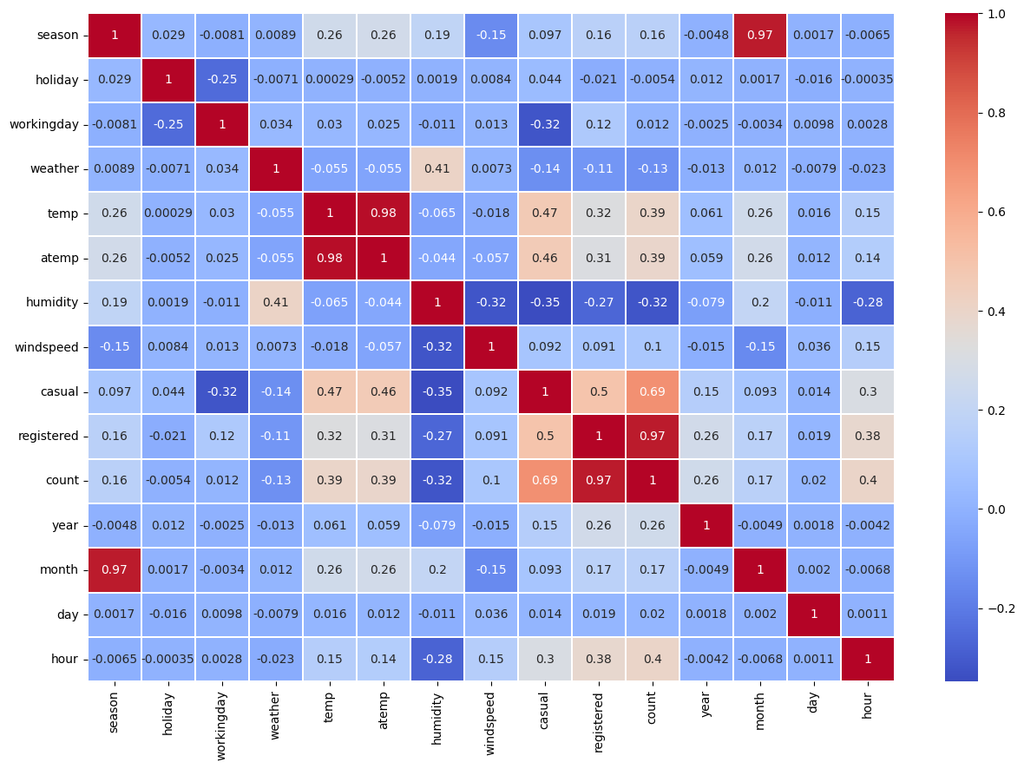

```python
sns.heatmap(train.corr(), annot=True, cmap="coolwarm", linewidths=0.1, annot_kws={"size":10})
fig = plt.gcf()
fig.set_size_inches(15,10)
plt.xticks()
plt.yticks()
plt.show()
```

b. 산점도(scatter plot)를 이용하여 데이터를 파악한다.

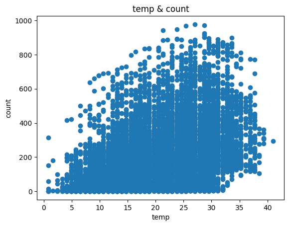

```python
# casual - count
fig, ax = plt.subplots()
ax.scatter(x = train["temp"], y = train["count"])
plt.xlabel("temp")
plt.ylabel("count")
plt.title("temp & count")
plt.show()
```

c. 커널밀도그래프(kde plot)를 이용하여 데이터를 파악한다.

- target인 count의 데이터 분포를 시각화한다.
- target의 왜도(skewness)를 파악하여 쏠림 정도를 확인할 수 있다.

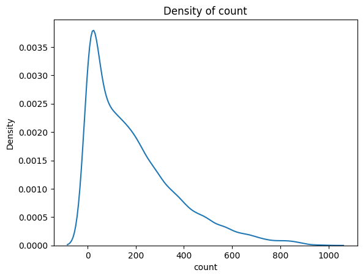

```python
sns.kdeplot(train["count"])
plt.xlabel("count")
plt.ylabel("Density")
plt.title("Density of count")
plt.show()
```

d. 박스플롯(box plot)를 이용하여 데이터를 파악한다.

- casual과 registered의 데이터 분포를 시각화한다.
- target인 count의 데이터 분포를 시각화한다.

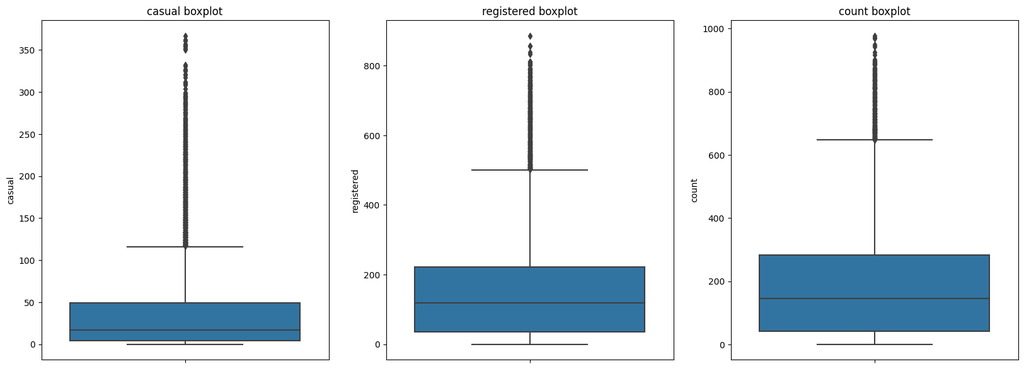

```python
figure, (ax1, ax2, ax3) = plt.subplots(1,3, figsize = (20,7))
sns.boxplot(y = "casual", data = train, ax = ax1)
sns.boxplot(y = "registered", data = train, ax = ax2)
sns.boxplot(y = "count", data = train, ax = ax3)

ax1.set_title("casual boxplot")
ax2.set_title("registered boxplot")
ax3.set_title("count boxplot")
plt.show()
```

e. 막대그래프(bar plot)을 이용하여 데이터 간 관계를 시각화한다.

e-1. datetime

```
+ year : 2012년이 2011년보다 대여량이 증가
+ month : 5~10월에 대여량이 높음, 6월에 가장 높은 대여량을 보여줌
+ day : 고르게 분포된 것을 보아 영향력이 크지 않은 것을 확인
+ hour : 오전 8시, 오후 5~6시에 높은 대여량을 보여줌(출퇴근 시간)
```

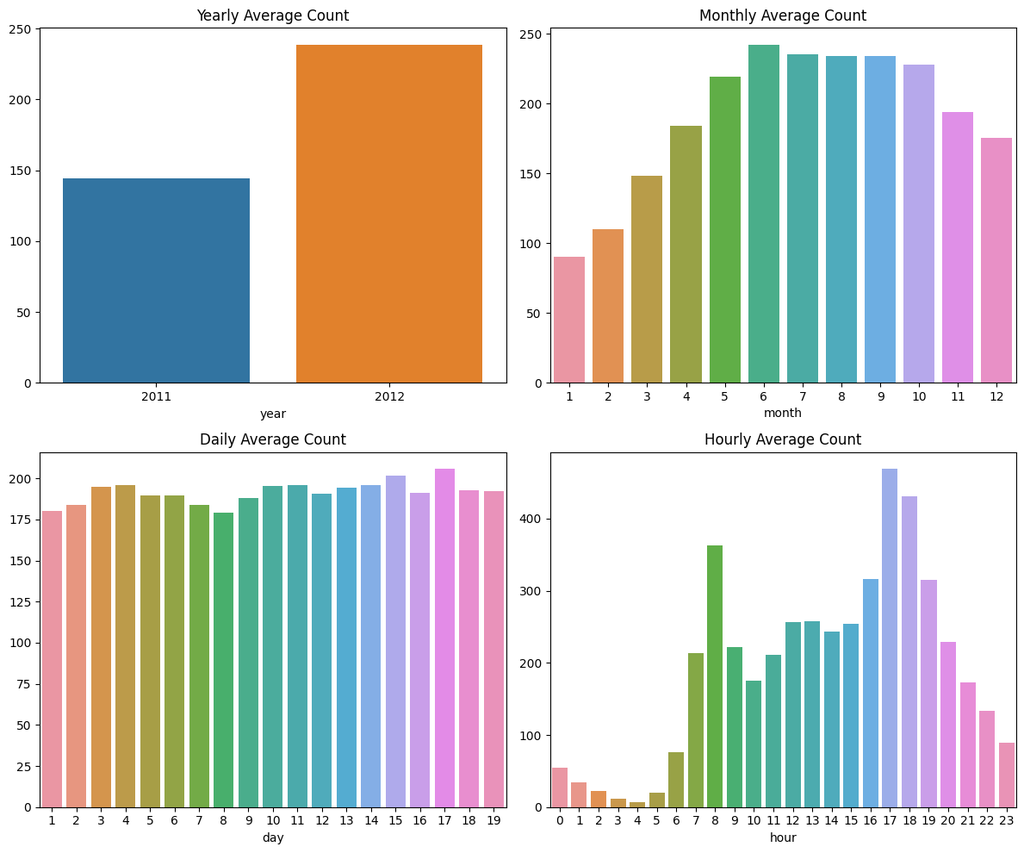

```python
# y축 : 평균 대여량
average_count_by_year = train.groupby('year')['count'].mean()
average_count_by_month = train.groupby('month')['count'].mean()
average_count_by_day = train.groupby('day')['count'].mean()
average_count_by_hour = train.groupby('hour')['count'].mean()

# Subplot 생성
fig, axs = plt.subplots(2, 2, figsize=(12, 10))
ax1, ax2, ax3, ax4 = axs.flatten()

# barplot 1: average_count_by_year
sns.barplot(x=average_count_by_year.index, y=average_count_by_year.values, ax=ax1)
ax1.set_title("Yearly Average Count")

# barplot 2: average_count_by_month
sns.barplot(x=average_count_by_month.index, y=average_count_by_month.values, ax=ax2)
ax2.set_title("Monthly Average Count")

# barplot 3: average_count_by_day
sns.barplot(x=average_count_by_day.index, y=average_count_by_day.values, ax=ax3)
ax3.set_title("Daily Average Count")

# barplot 4: average_count_by_hour
sns.barplot(x=average_count_by_hour.index, y=average_count_by_hour.values, ax=ax4)
ax4.set_title("Hourly Average Count")

# 그래프 작성
plt.tight_layout()
plt.show()
```

e-2. weather

```
+ 날씨가 좋을수록 높은 대여율을 나타내는 것을 확인할 수 있다.
+ 전처리 단계 때 weather가 4인 값은 이상치로 간주하여 처리한다.
```

```python
train.groupby("weather")[["datetime"]].count() / len(train)
```

| weather | datetime |
| --- | --- |
| 1 | 0.660665 |
| 2 | 0.260334 |
| 3 | 0.078909 |
| 4 | 0.000092 |

e-3. season

```
+ month에서 예측했던 5~10월에 높은 수치를 보여줬었고 season 역시 2,3분기에 높은 수치를 보이고 있다.
+ 이는 month와 season이 서로 연관되어 있는 것을 확인할 수 있다.
```

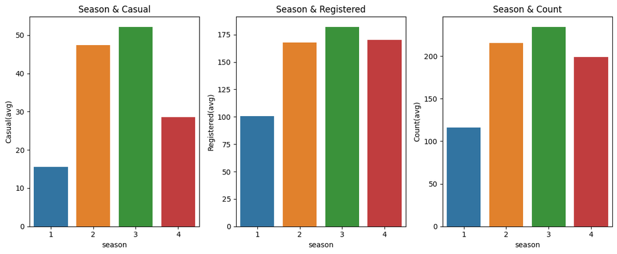

```python
# y축 데이터 설정
season_casual = train.groupby('season')['casual'].mean()
season_registered = train.groupby('season')['registered'].mean()
season_count = train.groupby('season')['count'].mean()

# Subplot 생성
fig, axs = plt.subplots(1, 3, figsize=(12, 5))
ax1, ax2, ax3 = axs.flatten()

# barplot 1: average_count_by_year
sns.barplot(x = season_casual.index, y = season_casual.values, ax = ax1)
ax1.set_title("Season & Casual")
ax1.set_ylabel("Casual(avg)")

# barplot 2: average_count_by_month
sns.barplot(x = season_registered.index, y = season_registered.values, ax = ax2)
ax2.set_title("Season & Registered")
ax2.set_ylabel("Registered(avg)")

# barplot 3: average_count_by_day
sns.barplot(x = season_count.index, y = season_count.values, ax = ax3)
ax3.set_title("Season & Count")
ax3.set_ylabel("Count(avg)")

# 그래프 작성
plt.tight_layout()
plt.show()
```

e-4. workingday, holiday

```
+ workingday가 0이면 weekend(주말), 1이면 workingday(평일)
+ holiday가 1이면 holiday(공휴일)
+ casual : 주말, 공휴일 / registered : 평일에 많이 분포되어 있다.
```

```python
train["period"] = "weekend"
is_holiday = train["holiday"] == 1
is_workingday = train["workingday"] == 1

train.loc[(is_holiday), "period"] = "holiday"
train.loc[(is_workingday), "period"] = "workingday"

train.head()
```

|  | datetime | season | holiday | workingday | weather | temp | atemp | humidity | windspeed | casual | registered | count | year | month | day | hour | period |
| --- | --- | --- | --- | --- | --- | --- | --- | --- | --- | --- | --- | --- | --- | --- | --- | --- | --- |
| 0 | 2011-01-01 00:00:00 | 1 | 0 | 0 | 1 | 9.84 | 14.395 | 81 | 0.0 | 3 | 13 | 16 | 2011 | 1 | 1 | 0 | weekend |
| 1 | 2011-01-01 01:00:00 | 1 | 0 | 0 | 1 | 9.02 | 13.635 | 80 | 0.0 | 8 | 32 | 40 | 2011 | 1 | 1 | 1 | weekend |
| 2 | 2011-01-01 02:00:00 | 1 | 0 | 0 | 1 | 9.02 | 13.635 | 80 | 0.0 | 5 | 27 | 32 | 2011 | 1 | 1 | 2 | weekend |
| 3 | 2011-01-01 03:00:00 | 1 | 0 | 0 | 1 | 9.84 | 14.395 | 75 | 0.0 | 3 | 10 | 13 | 2011 | 1 | 1 | 3 | weekend |
| 4 | 2011-01-01 04:00:00 | 1 | 0 | 0 | 1 | 9.84 | 14.395 | 75 | 0.0 | 0 | 1 | 1 | 2011 | 1 | 1 | 4 | weekend |

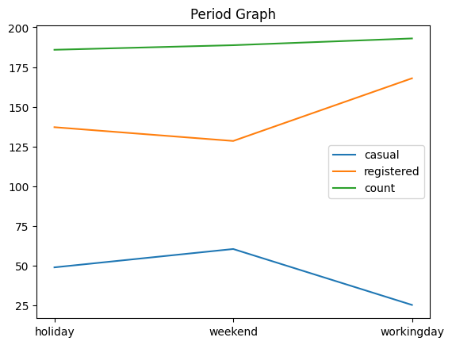

```python
period_plot = (train.groupby("period")[["casual", "registered", "count"]].sum() / train.groupby("period")[["casual", "registered", "count"]].count())

plt.plot(period_plot)
plt.title("Period Graph")
plt.legend(period_plot.columns)
plt.show()
```

f. 전체 종합(시간별 그래프)

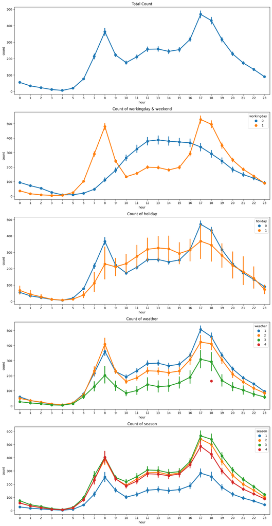

```python
fig, axs = plt.subplots(5, 1, figsize = (15,30))
ax1, ax2, ax3, ax4, ax5 = axs.flatten()

sns.pointplot(x = "hour", y = "count", data = train, ax = ax1)
ax1.set_title("Total Count")
sns.pointplot(x = "hour", y = "count", data = train, hue = "workingday", ax = ax2)
ax2.set_title("Count of workingday & weekend")
sns.pointplot(x = "hour", y = "count", data = train, hue = "holiday", ax = ax3)
ax3.set_title("Count of holiday")
sns.pointplot(x = "hour", y = "count", data = train, hue = "weather", ax = ax4)
ax4.set_title("Count of weather")
sns.pointplot(x = "hour", y = "count", data = train, hue = "season", ax = ax5)
ax5.set_title("Count of season")
plt.show()
```

# 4. 데이터 전처리(preprocessing)

- 결측치는 존재하지 않기 때문에 따로 처리할 필요는 없다.
- 이상치(outlier)을 처리한다.
- 불필요한 행은 제거한다.

```python
train.head()
```

|  | datetime | season | holiday | workingday | weather | temp | atemp | humidity | windspeed | casual | registered | count | year | month | day | hour | period |
| --- | --- | --- | --- | --- | --- | --- | --- | --- | --- | --- | --- | --- | --- | --- | --- | --- | --- |
| 0 | 2011-01-01 00:00:00 | 1 | 0 | 0 | 1 | 9.84 | 14.395 | 81 | 0.0 | 3 | 13 | 16 | 2011 | 1 | 1 | 0 | weekend |
| 1 | 2011-01-01 01:00:00 | 1 | 0 | 0 | 1 | 9.02 | 13.635 | 80 | 0.0 | 8 | 32 | 40 | 2011 | 1 | 1 | 1 | weekend |
| 2 | 2011-01-01 02:00:00 | 1 | 0 | 0 | 1 | 9.02 | 13.635 | 80 | 0.0 | 5 | 27 | 32 | 2011 | 1 | 1 | 2 | weekend |
| 3 | 2011-01-01 03:00:00 | 1 | 0 | 0 | 1 | 9.84 | 14.395 | 75 | 0.0 | 3 | 10 | 13 | 2011 | 1 | 1 | 3 | weekend |
| 4 | 2011-01-01 04:00:00 | 1 | 0 | 0 | 1 | 9.84 | 14.395 | 75 | 0.0 | 0 | 1 | 1 | 2011 | 1 | 1 | 4 | weekend |

```python
train.info()
```

```
<class 'pandas.core.frame.DataFrame'>
RangeIndex: 10886 entries, 0 to 10885
Data columns (total 17 columns):
 #   Column      Non-Null Count  Dtype
---  ------      --------------  -----
 0   datetime    10886 non-null  datetime64[ns]
 1   season      10886 non-null  int64
 2   holiday     10886 non-null  int64
 3   workingday  10886 non-null  int64
 4   weather     10886 non-null  int64
 5   temp        10886 non-null  float64
 6   atemp       10886 non-null  float64
 7   humidity    10886 non-null  int64
 8   windspeed   10886 non-null  float64
 9   casual      10886 non-null  int64
 10  registered  10886 non-null  int64
 11  count       10886 non-null  int64
 12  year        10886 non-null  int64
 13  month       10886 non-null  int64
 14  day         10886 non-null  int64
 15  hour        10886 non-null  int64
 16  period      10886 non-null  object
dtypes: datetime64[ns](1), float64(3), int64(12), object(1)
memory usage: 1.4+ MB
```

a. 이상치 처리

- weather가 4인 값은 이상치로 간주하여 처리한다.

```python
train = train.loc[train["weather"]!=4]
train.info()
```

```
<class 'pandas.core.frame.DataFrame'>
Int64Index: 10885 entries, 0 to 10885
Data columns (total 17 columns):
 #   Column      Non-Null Count  Dtype
---  ------      --------------  -----
 0   datetime    10885 non-null  datetime64[ns]
 1   season      10885 non-null  int64
 2   holiday     10885 non-null  int64
 3   workingday  10885 non-null  int64
 4   weather     10885 non-null  int64
 5   temp        10885 non-null  float64
 6   atemp       10885 non-null  float64
 7   humidity    10885 non-null  int64
 8   windspeed   10885 non-null  float64
 9   casual      10885 non-null  int64
 10  registered  10885 non-null  int64
 11  count       10885 non-null  int64
 12  year        10885 non-null  int64
 13  month       10885 non-null  int64
 14  day         10885 non-null  int64
 15  hour        10885 non-null  int64
 16  period      10885 non-null  object
dtypes: datetime64[ns](1), float64(3), int64(12), object(1)
memory usage: 1.5+ MB
```

- count의 평균과 표준편차를 구하여 z-score 값을 계산한다.
- 계산된 z-score 값을 이용하여 이상치의 범주를 설정한다.

```python
mean_count = train["count"].mean()
std_count = train["count"].std()
threshold_count = mean_count + 3 * std_count
train = train[train["count"] < threshold_count]
train.info()
```

```
<class 'pandas.core.frame.DataFrame'>
Int64Index: 10738 entries, 0 to 10885
Data columns (total 17 columns):
 #   Column      Non-Null Count  Dtype
---  ------      --------------  -----
 0   datetime    10738 non-null  datetime64[ns]
 1   season      10738 non-null  int64
 2   holiday     10738 non-null  int64
 3   workingday  10738 non-null  int64
 4   weather     10738 non-null  int64
 5   temp        10738 non-null  float64
 6   atemp       10738 non-null  float64
 7   humidity    10738 non-null  int64
 8   windspeed   10738 non-null  float64
 9   casual      10738 non-null  int64
 10  registered  10738 non-null  int64
 11  count       10738 non-null  int64
 12  year        10738 non-null  int64
 13  month       10738 non-null  int64
 14  day         10738 non-null  int64
 15  hour        10738 non-null  int64
 16  period      10738 non-null  object
dtypes: datetime64[ns](1), float64(3), int64(12), object(1)
memory usage: 1.5+ MB
```

b. count 정규화(scaling)

- 정규화를 통해 데이터의 분포를 조정한다.
- 로그(log) 변환을 이용하여 정규화를 진행한다.
- 변환한 변수를 count_scaled 변수에 저장한다.

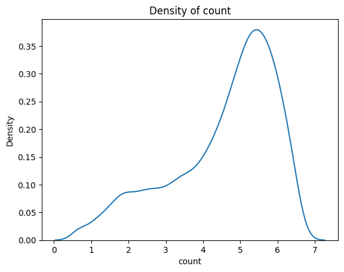

```python
train["count"] = np.log1p(train["count"])
sns.kdeplot(train["count"])
plt.xlabel("count")
plt.ylabel("Density")
plt.title("Density of count")
plt.show()

count_scaled = train["count"]
```

c. 불필요한 데이터 처리

- 모델링에 불필요한 행을 제거한다.

```python
train_df = train.drop(["datetime","period","casual","registered","count"], axis = 1)
train_df.head()
```

|  | season | holiday | workingday | weather | temp | atemp | humidity | windspeed | year | month | day | hour |
| --- | --- | --- | --- | --- | --- | --- | --- | --- | --- | --- | --- | --- |
| 0 | 1 | 0 | 0 | 1 | 9.84 | 14.395 | 81 | 0.0 | 2011 | 1 | 1 | 0 |
| 1 | 1 | 0 | 0 | 1 | 9.02 | 13.635 | 80 | 0.0 | 2011 | 1 | 1 | 1 |
| 2 | 1 | 0 | 0 | 1 | 9.02 | 13.635 | 80 | 0.0 | 2011 | 1 | 1 | 2 |
| 3 | 1 | 0 | 0 | 1 | 9.84 | 14.395 | 75 | 0.0 | 2011 | 1 | 1 | 3 |
| 4 | 1 | 0 | 0 | 1 | 9.84 | 14.395 | 75 | 0.0 | 2011 | 1 | 1 | 4 |

```python
test_df = test.drop(["datetime"], axis = 1)
test_df.head()
```

|  | season | holiday | workingday | weather | temp | atemp | humidity | windspeed | year | month | day | hour |
| --- | --- | --- | --- | --- | --- | --- | --- | --- | --- | --- | --- | --- |
| 0 | 1 | 0 | 1 | 1 | 10.66 | 11.365 | 56 | 26.0027 | 2011 | 1 | 20 | 0 |
| 1 | 1 | 0 | 1 | 1 | 10.66 | 13.635 | 56 | 0.0000 | 2011 | 1 | 20 | 1 |
| 2 | 1 | 0 | 1 | 1 | 10.66 | 13.635 | 56 | 0.0000 | 2011 | 1 | 20 | 2 |
| 3 | 1 | 0 | 1 | 1 | 10.66 | 12.880 | 56 | 11.0014 | 2011 | 1 | 20 | 3 |
| 4 | 1 | 0 | 1 | 1 | 10.66 | 12.880 | 56 | 11.0014 | 2011 | 1 | 20 | 4 |

# 5. 데이터 모델링(Data Modeling)

```python
from sklearn.model_selection import KFold, cross_val_score
from sklearn.metrics import mean_squared_error
from sklearn.pipeline import make_pipeline
from sklearn.ensemble import RandomForestRegressor, GradientBoostingRegressor
from xgboost import XGBRegressor
from lightgbm import LGBMRegressor
from sklearn.linear_model import ElasticNet, Lasso, LinearRegression
from sklearn.preprocessing import MinMaxScaler
```

a. Min-Max Scaling

```python
model = MinMaxScaler()

train_scaled = model.fit_transform(train_df)
test_scaled = model.transform(test_df)

train_scaled
```

```
array([[0.        , 0.        , 0.        , ..., 0.        , 0.        ,
        0.        ],
       [0.        , 0.        , 0.        , ..., 0.        , 0.        ,
        0.04347826],
       [0.        , 0.        , 0.        , ..., 0.        , 0.        ,
        0.08695652],
       ...,
       [1.        , 0.        , 1.        , ..., 1.        , 1.        ,
        0.91304348],
       [1.        , 0.        , 1.        , ..., 1.        , 1.        ,
        0.95652174],
       [1.        , 0.        , 1.        , ..., 1.        , 1.        ,
        1.        ]])
```

b. K-Fold 교차검증

```python
from sklearn.model_selection import cross_val_score, StratifiedKFold

kfold = KFold(n_splits=5)
random_state = 42
models = [
    ("Lasso", Lasso(random_state=random_state)),
    ("ElasticNet", ElasticNet(random_state=random_state)),
    ("RandomForest", RandomForestRegressor(random_state=random_state)),
    ("GradientBoost", GradientBoostingRegressor(random_state=random_state)),
    ("XGBoost", XGBRegressor(random_state=random_state)),
    ("LGBM", LGBMRegressor(random_state=random_state, force_row_wise=True))
]

reg_mean = []
reg_std = []

for name, regre in models:
    # 음수의 MSE 값이 낮을수록 모델의 예측 성능이 더 좋음
    mse_scores = cross_val_score(
        regre, train_scaled, count_scaled, scoring='neg_mean_squared_error', cv=kfold)

    # RMSE 계산 후 저장
    reg_mean.append(np.mean(np.sqrt(-mse_scores)))
    reg_std.append(np.std(np.sqrt(-mse_scores)))

# 모델 이름 추출(index를 모델 이름으로 지정하여 가시성 상승)
model_names = [name for name, _ in models]

# reg_df 데이터프레임 생성
reg_df = pd.DataFrame({"CrossValMeans": reg_mean, "CrossValErrors": reg_std}, index = model_names)

reg_df
```

[output not shown]

|  | CrossValMeans | CrossValErrors |
| --- | --- | --- |
| Lasso | 1.432510 | 0.086091 |
| ElasticNet | 1.432510 | 0.086091 |
| RandomForest | 0.461547 | 0.129689 |
| GradientBoost | 0.464815 | 0.122082 |
| XGBoost | 0.420798 | 0.117011 |
| LGBM | 0.408813 | 0.137367 |

c. K-Fold 교차검정 결과(성능이 우수한 순서로 나열)

```
1. LGBM : 0.408813
2. XGBoost : 0.420798
3. RandomForest : 0.461547
4. GradientBoosting : 0.464815
5. Lasso : 1.432510
6. ElasticNet : 1.432510
```

=> 성능이 가장 좋게 나온 LGBM을 활용하기로 하였다.

d. 모델 테스트

```python
import lightgbm as lgb
import logging
from lightgbm import LGBMRegressor

# Suppress LightGBM warnings
logging.getLogger('lightgbm').setLevel(logging.ERROR)

# Gradient boosting 파라미터 튜닝
model = LGBMRegressor(n_estimators=300, objective="regression", learning_rate=0.05, max_depth=4, reg_lambda=1, subsample=0.5, random_state=42, verbose=-1)
model.fit(train_scaled, count_scaled)
```

```
LGBMRegressor(learning_rate=0.05, max_depth=4, n_estimators=300,
              objective='regression', random_state=42, reg_lambda=1,
              subsample=0.5, verbose=-1)
```

e. 모델 예측

- 예측 결과를 result 데이터프레임에 담아서 결과를 확인한다.

```python
predictions = model.predict(test_scaled)
print(predictions)

result = pd.DataFrame({
    "datetime": test["datetime"],
    "count": np.expm1(predictions)
})

result
```

```
[2.2613018  1.79672083 1.32492606 ... 4.8231916  4.6498678  4.28408197]
```

|  | datetime | count |
| --- | --- | --- |
| 0 | 2011-01-20 00:00:00 | 8.595573 |
| 1 | 2011-01-20 01:00:00 | 5.029842 |
| 2 | 2011-01-20 02:00:00 | 2.761907 |
| 3 | 2011-01-20 03:00:00 | 1.703219 |
| 4 | 2011-01-20 04:00:00 | 1.621275 |
| ... | ... | ... |
| 6488 | 2012-12-31 19:00:00 | 265.944964 |
| 6489 | 2012-12-31 20:00:00 | 172.940152 |
| 6490 | 2012-12-31 21:00:00 | 123.361370 |
| 6491 | 2012-12-31 22:00:00 | 103.571161 |
| 6492 | 2012-12-31 23:00:00 | 71.535926 |

6493 rows × 2 columns

# 6. 결론(Conclusion)

i. 수요 예측 및 season 패턴

```
- 데이터셋을 기반으로 수요의 시즌 패턴을 분석하여, 특정 시간대나 날짜에 따른 수요의 변동 패턴을 식별할 수 있었다.
- 이러한 정보는 향후 자전거 대여와 관련된 마케팅 및 자원 할당에 참고자료로 활용될 수 있을 것이다.
```

ii. weather과의 상관관계

```
- 날씨 데이터와 bike sharing 데이터 간의 상관관계를 조사하여, 특정 날씨 조건이나 기상 변화가 자전거 수요에 어떤 영향을 미치는지 분석할 수 있었다.
- 날씨가 맑은 날과 구름이 낀 날, 비가 오거나 눈이 오는 날에 따른 수요 증감 등을 확인할 수 있었다.
```

iii. workingday, weekend, holiday 영향

[output not shown]

iv. 시간대별 수요 변화

```
- 시간대에 따른 수요의 변화를 분석하여, 특정 시간대에 수요가 높아지거나 낮아지는 경향이 있는지 확인할 수 있었다.
- 이를 기반으로 자원 할당을 최적화할 수 있었다.
```

v. 사용자 유형에 따른 수요 분석

```
- 데이터를 기반으로 비회원(casual)과 회원(registered), 또는 각 사용자 유형별로 수요 패턴을 분석하였다.
- 각 유형에 맞는 서비스 개선이나 마케팅 전략을 수립할 수 있는 자료가 될 것이다.
```

# 7. 기타사항(Etc)

a. 참고 문서

- [Kaggle/Bike Sharing Demand](https://www.kaggle.com/competitions/bike-sharing-demand/)
- [teddylee777 Github](https://github.com/teddylee777/machine-learning/blob/master/01-Kaggle/01-Kaggle/02-bike-sharing-demand/bike_sharing_demand.ipynb)

b. html 변환 코드

```python
%%shell
jupyter nbconvert --to html /content/Bike_Sharing_Demand.ipynb
```

```
[NbConvertApp] Converting notebook /content/Bike_Sharing_Demand.ipynb to html
[NbConvertApp] Writing 1798053 bytes to /content/Bike_Sharing_Demand.html
```